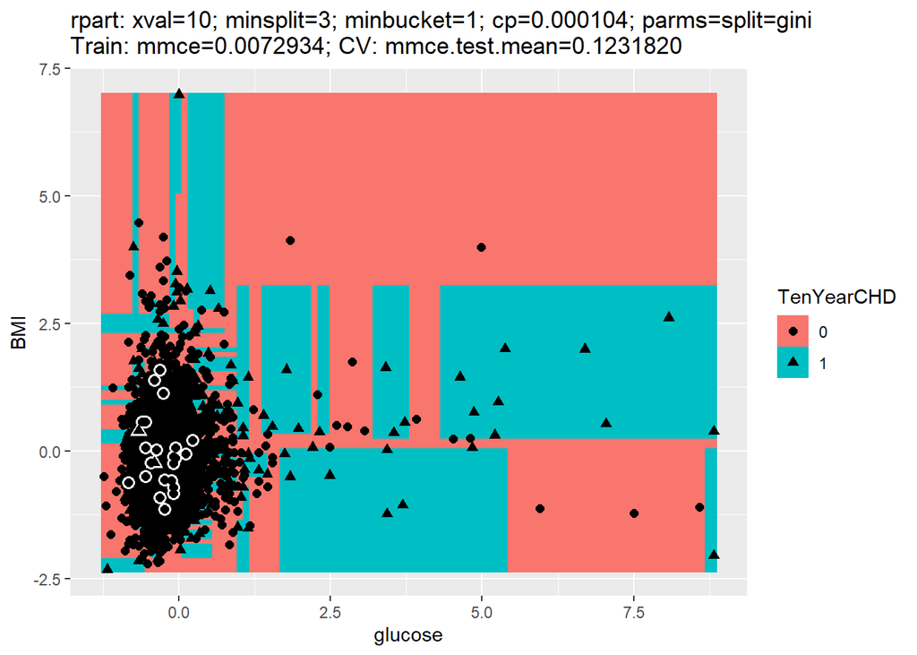

```r
plotLearnerPrediction(cart_lrn, task = c50_task,
                      features = c("glucose", "BMI"))
```

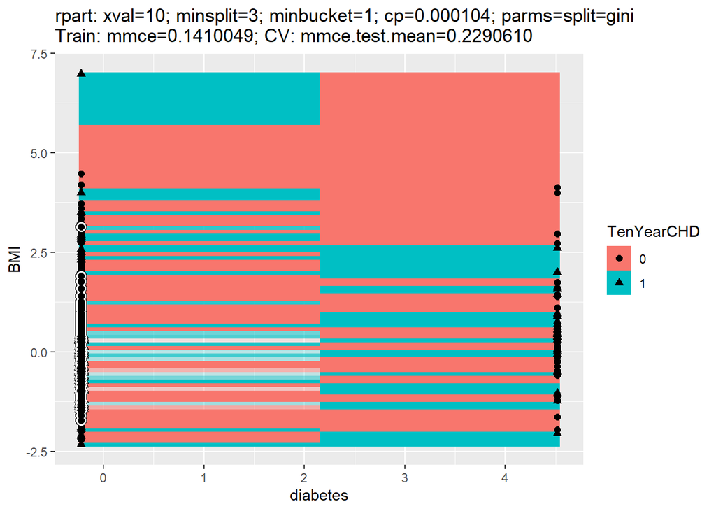

```r
plotLearnerPrediction(cart_lrn, task = c50_task,
                      features = c("diabetes", "BMI"))
```

```r
### Performance measure suitable for the neural network classification task
listMeasures(c50_task)
```

```
##  [1] "tnr"              "tpr"              "featperc"         "f1"
##  [5] "mmce"             "mcc"              "brier.scaled"     "lsr"
##  [9] "bac"              "fn"               "fp"               "fnr"
## [13] "qsr"              "fpr"              "npv"              "brier"
## [17] "auc"              "timeboth"         "multiclass.aunp"  "timetrain"
## [21] "multiclass.aunu"  "ber"              "timepredict"      "multiclass.brier"
## [25] "ssr"              "ppv"              "acc"              "logloss"
## [29] "wkappa"           "tn"               "tp"               "multiclass.au1p"
## [33] "multiclass.au1u"  "fdr"              "kappa"            "gpr"
## [37] "gmean"
```

```r
### Get the default measure for neural network learner
getDefaultMeasure(c50_lrn)
```

```
## Name: Mean misclassification error
## Performance measure: mmce
## Properties: classif,classif.multi,req.pred,req.truth
## Minimize: TRUE
## Best: 0; Worst: 1
## Aggregated by: test.mean
## Arguments:
## Note: Defined as: mean(response != truth)
```

```r
# performance of prediction
performance(test_pred) # default mmce
```

```
##      mmce
## 0.3371141
```

```r
performance(test_pred, measures=acc)
```

```
##       acc
## 0.6628859
```

For relative confusion matrix between glucose and diabetes. There are no absolute certainty of relationship between diabetes and glucose for confirming the patients has CHD in 10 years.

For relative confusion matrix between BMI and glucose. Patients who has high numerical value of glucose and high numerical value of BMI not tend to have CHD in 10 years.

For relative confusion matrix between BMI and diabetes. Patients who has over 5.5 numerical value of BMI and no diabetes tend to have CHD in 10 years.Patients who has high numerical value of BMI and diabetes not tend to have CHD in 10 years.

```r
## Define the resampling strategy
rdesc <- makeResampleDesc(method = "CV", iters=10)
# tune CF
num_ps <- makeParamSet(
  makeNumericParam("CF", lower = -5, upper = 0, trafo =
                     function(x) 10^x)
)
ctrl <- makeTuneControlRandom(maxit = 200L)
res <- tuneParams(c50_lrn, task = c50_task,
                  resampling = rdesc,
                  par.set = num_ps,
                  control = ctrl,
                  measures = list(acc, mmce),
                  show.info = FALSE)
res
```

```
## Tune result:
## Op. pars: CF=0.483
## acc.test.mean=0.8173898,mmce.test.mean=0.1826102
```

```r
res$x
```

```
## $CF
## [1] 0.4825941
```

```r
res$y
```

```
##  acc.test.mean mmce.test.mean
##      0.8173898      0.1826102
```

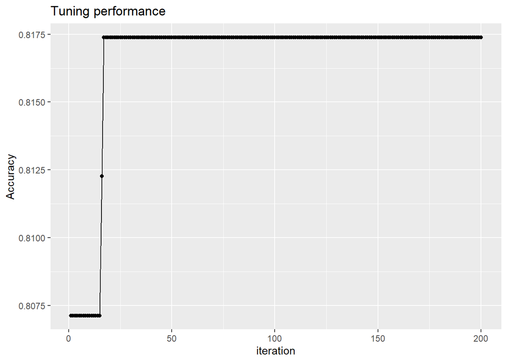

```r
#investigating hyperparameter tuning effects
data <- generateHyperParsEffectData(res, trafo=TRUE)
pl <- plotHyperParsEffect(data, x = "iteration", y = "acc.test.mean",
                          plot.type = "line")
library(ggplot2)
# use ggplot2 function to change y-axis label and add title
pl + ggtitle("Tuning performance") + ylab("Accuracy")
```